# Kashyap_HW5

Madhuri

2022-11-19

## Homework 5

```r
library(janitor)
```

```r
library(tidymodels)
library(tidyverse)
library(ggplot2)
library(caret)
library(broom)
library(boot)

df <- read.csv("Pokemon.csv")
```

### Question 1

```r
df_clean <- as_tibble(df) %>%
  clean_names()
```

The clean_names() function altered the column names, making them more readable This has obvious benefits in increasing usability by making all the characters lower case and removing any special symbols.

### Question 2

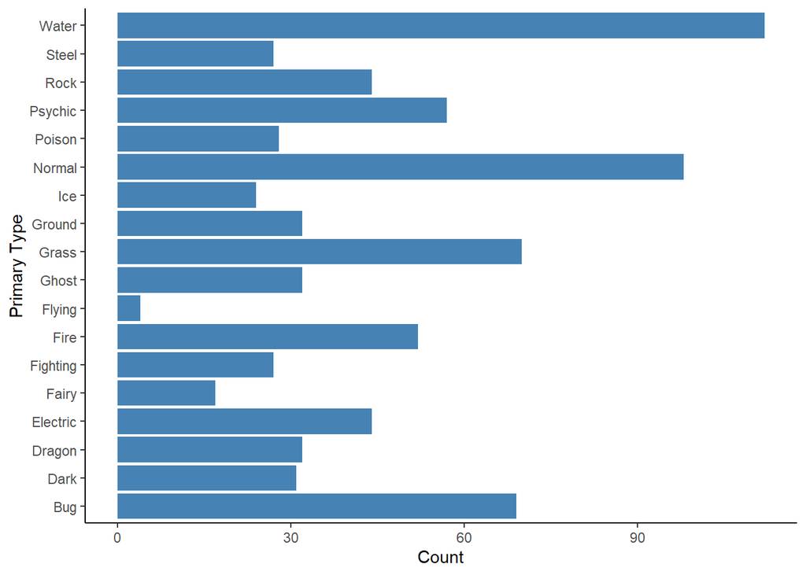

```r
#barplot
ggplot(df_clean, aes(x = type_1)) +
  geom_bar(stat = "count", fill = "steelblue") +
  theme_classic() +
  coord_flip() +
  xlab("Primary Type") +
  ylab("Count")
```

```r
#number of classes =18
summary(factor(df_clean$type_1))
```

```
##      Bug     Dark   Dragon Electric    Fairy Fighting     Fire   Flying
##       69       31       32       44       17       27       52        4
##    Ghost    Grass   Ground      Ice   Normal   Poison  Psychic     Rock
##       32       70       32       24       98       28       57       44
##    Steel    Water
##       27      112
```

```r
#filtering data
df_filtered <- filter(df_clean, type_1 == "Bug" | type_1 == "Fire" | type_1 == "Grass" |
                        type_1 == "Normal" | type_1 == "Water" | type_1 == "Psychic")
#checking new dataframe
summary(factor(df_filtered$type_1))
```

```
##     Bug    Fire   Grass  Normal Psychic   Water
##      69      52      70      98      57     112
```

```r
#converting to factors
df_filtered$type_1 <- as.factor(df_filtered$type_1)
df_filtered$legendary <- as.factor(df_filtered$legendary)
df_filtered$generation <- as.factor(df_filtered$generation)
```

There are 18 classes of primary types of Pokemon. The Flying an Fairy classes have the lowest number of Pokemon with 4 and 17, respectively.

### Question 3

```r
set.seed(1212)
df_split <- initial_split(df_filtered, strata = "type_1")

df_train <- training(df_split)
df_test <- testing(df_split)

df_fold <- vfold_cv(df_train, v = 5, strata = "type_1")
```

Stratified k-fold cross=validation is particularly useful in cases like our where the variable of interest (type_1) is imbalanced, implying that the frequencies of the classes withing that variable are not equally distributed. This type of cross-validation then allows us to ensure that each of the folds have a similar distribution of data withing type_1 as the original data frame.

### Question 4

```r
#recipe
simple_rec1 <- recipe(type_1 ~ legendary + generation + sp_atk + attack + speed + defense +
                        hp + sp_def, data = df_train)

pokemon_recipe <- simple_rec1 %>%
  step_dummy(legendary) %>%
  step_dummy(generation) %>%
  step_center(all_numeric_predictors()) %>%
  step_scale(all_numeric_predictors())
pokemon_recipe
```

```
## Recipe
##
## Inputs:
##
##       role #variables
##    outcome          1
##  predictor          8
##
## Operations:
##
## Dummy variables from legendary
## Dummy variables from generation
## Centering for all_numeric_predictors()
## Scaling for all_numeric_predictors()
```

### Question 5

```r
#model
reg1 <- multinom_reg(mixture = tune(), penalty = tune()) %>%
  set_engine("glmnet")

#workflow
elastic_workflow <- workflow() %>%
  add_recipe(pokemon_recipe) %>%
  add_model(reg1)

#tuning penalty
penalty_grid <- grid_regular(penalty(range = c(-5, 5)), levels = 10)
penalty_grid
```

```
## # A tibble: 10 × 1
##          penalty
##            <dbl>
##  1      0.00001
##  2      0.000129
##  3      0.00167
##  4      0.0215
##  5      0.278
##  6      3.59
##  7     46.4
##  8    599.
##  9   7743.
## 10 100000
```

```r
mixture_grid <- grid_random(mixture(range = c(0,1)), size = 10)
mixture_grid
```

```
## # A tibble: 10 × 1
##    mixture
##      <dbl>
##  1  0.281
##  2  0.180
##  3  0.0564
##  4  0.726
##  5  0.664
##  6  0.871
##  7  0.0677
##  8  0.656
##  9  0.226
## 10  0.0408
```

```r
#combining grids to one dataframe
grid_df <- as.data.frame(c(penalty_grid,mixture_grid))
```

### Question 6

```r
#fitting model
tuned_mod <- tune_grid(elastic_workflow,
                       resamples = df_fold,
                       grid = grid_df)
tuned_mod
```

```
## # Tuning results
## # 5-fold cross-validation using stratification
## # A tibble: 5 × 4
##   splits           id    .metrics          .notes
##   <list>           <chr> <list>            <list>
## 1 <split [270/71]> Fold1 <tibble [20 × 6]> <tibble [0 × 3]>
## 2 <split [271/70]> Fold2 <tibble [20 × 6]> <tibble [0 × 3]>
## 3 <split [273/68]> Fold3 <tibble [20 × 6]> <tibble [0 × 3]>
## 4 <split [274/67]> Fold4 <tibble [20 × 6]> <tibble [0 × 3]>
## 5 <split [276/65]> Fold5 <tibble [20 × 6]> <tibble [0 × 3]>
```

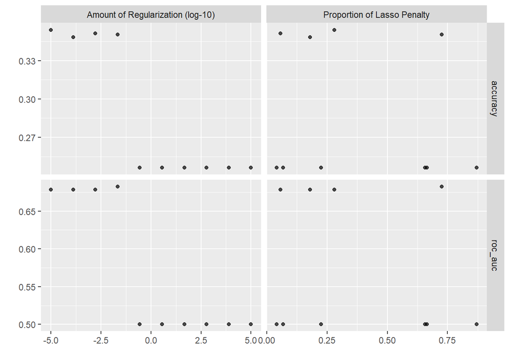

```r
autoplot(tuned_mod)
```

```r
collect_metrics(tuned_mod)
```

```
## # A tibble: 20 × 8
##          penalty mixture .metric  .estimator  mean     n std_err .config
##            <dbl>   <dbl> <chr>    <chr>      <dbl> <int>   <dbl> <chr>
##  1 100000         0.0408 accuracy multiclass 0.246     5 0.00253 Preprocessor1_…
##  2 100000         0.0408 roc_auc  hand_till  0.5       5 0       Preprocessor1_…
##  3      0.00167   0.0564 accuracy multiclass 0.351     5 0.0169  Preprocessor1_…
##  4      0.00167   0.0564 roc_auc  hand_till  0.678     5 0.0113  Preprocessor1_…
##  5     46.4       0.0677 accuracy multiclass 0.246     5 0.00253 Preprocessor1_…
##  6     46.4       0.0677 roc_auc  hand_till  0.5       5 0       Preprocessor1_…
##  7      0.000129  0.180  accuracy multiclass 0.348     5 0.0157  Preprocessor1_…
##  8      0.000129  0.180  roc_auc  hand_till  0.679     5 0.0106  Preprocessor1_…
##  9   7743.        0.226  accuracy multiclass 0.246     5 0.00253 Preprocessor1_…
## 10   7743.        0.226  roc_auc  hand_till  0.5       5 0       Preprocessor1_…
## 11      0.00001   0.281  accuracy multiclass 0.354     5 0.0162  Preprocessor1_…
## 12      0.00001   0.281  roc_auc  hand_till  0.679     5 0.0107  Preprocessor1_…
## 13    599.        0.656  accuracy multiclass 0.246     5 0.00253 Preprocessor1_…
## 14    599.        0.656  roc_auc  hand_till  0.5       5 0       Preprocessor1_…
## 15      0.278     0.664  accuracy multiclass 0.246     5 0.00253 Preprocessor1_…
## 16      0.278     0.664  roc_auc  hand_till  0.5       5 0       Preprocessor1_…
## 17      0.0215    0.726  accuracy multiclass 0.350     5 0.0322  Preprocessor1_…
## 18      0.0215    0.726  roc_auc  hand_till  0.682     5 0.0175  Preprocessor1_…
## 19      3.59      0.871  accuracy multiclass 0.246     5 0.00253 Preprocessor1_…
## 20      3.59      0.871  roc_auc  hand_till  0.5       5 0       Preprocessor1_…
```

Accuracy and ROC AUC are maximized at smaller penalty values however, mixture has a more variable effect with mostly lower values, but also one higher value allowing for maximization. On average, lower values of both penalty and mixture yield better accuracy and ROC AUC values.

### Question 7

```r
#best model
best_fit <- select_best(tuned_mod, metric = "roc_auc")
best_fit
```

```
## # A tibble: 1 × 3
##   penalty mixture .config
##     <dbl>   <dbl> <chr>
## 1  0.0215   0.726 Preprocessor1_Model09
```

```r
#finalizing workflow
final_mod <- finalize_workflow(elastic_workflow, best_fit)

#applying model to training data
final_fit <- fit(final_mod, data = df_train)

#applying to testing data
test_mod <- augment(final_fit, new_data = df_test)


roc_auc(test_mod,truth = type_1, estimate = .pred_Bug:.pred_Water)
```

```
## # A tibble: 1 × 3
##   .metric .estimator .estimate
##   <chr>   <chr>          <dbl>
## 1 roc_auc hand_till      0.687
```

```r
accuracy(test_mod, truth = type_1, estimate = .pred_class)
```

```
## # A tibble: 1 × 3
##   .metric  .estimator .estimate
##   <chr>    <chr>          <dbl>
## 1 accuracy multiclass     0.333
```

```r
##33% accuracy - not great

conf_mat(test_mod, truth = type_1, estimate = .pred_class)
```

```
##           Truth
## Prediction Bug Fire Grass Normal Psychic Water
##    Bug       3    0     2      2       0     1
##    Fire      0    0     0      0       0     0
##    Grass     0    0     1      0       2     1
##    Normal   10    2     2     16       1     9
##    Psychic   1    1     1      2       4     2
##    Water     4   10    12      5       8    15
```

```r
#clearly some major issues with specific classes, particularly Fire
```

Model accuracy for predicting class in testing data is relatively low at 33%. The problem also seems largely concentrated within specific classes, like Fire which the model is not predicting at all

### Question 8

```r
#roc curve for training data
augment(final_fit, new_data = df_train) %>%
  roc_auc(type_1, .pred_Bug:.pred_Water)
```

```
## # A tibble: 1 × 3
##   .metric .estimator .estimate
##   <chr>   <chr>          <dbl>
## 1 roc_auc hand_till      0.747
```

```r
#roc for testing data
roc_auc(test_mod, type_1, .pred_Bug:.pred_Water)
```

```
## # A tibble: 1 × 3
##   .metric .estimator .estimate
##   <chr>   <chr>          <dbl>
## 1 roc_auc hand_till      0.687
```

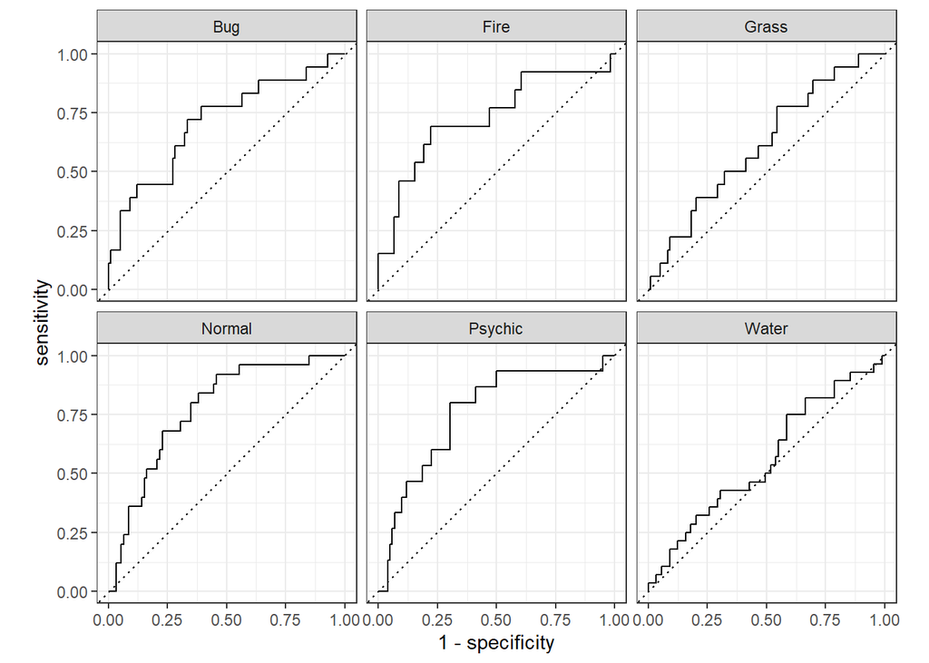

```r
#roc curves for each type
roc_curve(test_mod, type_1, .pred_Bug:.pred_Water) %>%
  autoplot()
```

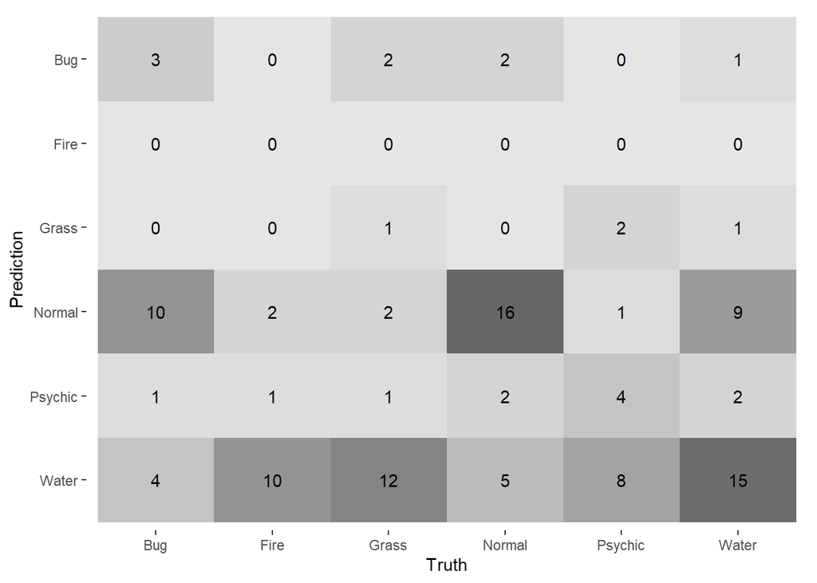

```r
#heatmap
test_mod %>%
  conf_mat(truth = type_1, estimate = .pred_class) %>%
  autoplot(type = "heatmap")
```

### Question 9

```r
x <- c(rep(1, 337), rep(0, 421))

resamples <- lapply(1:1000, function(i) sample(x, replace = T))

boot.mean <- sapply(resamples, mean)
boot.mean
```

[output not shown]

[output cut: 128 more lines]

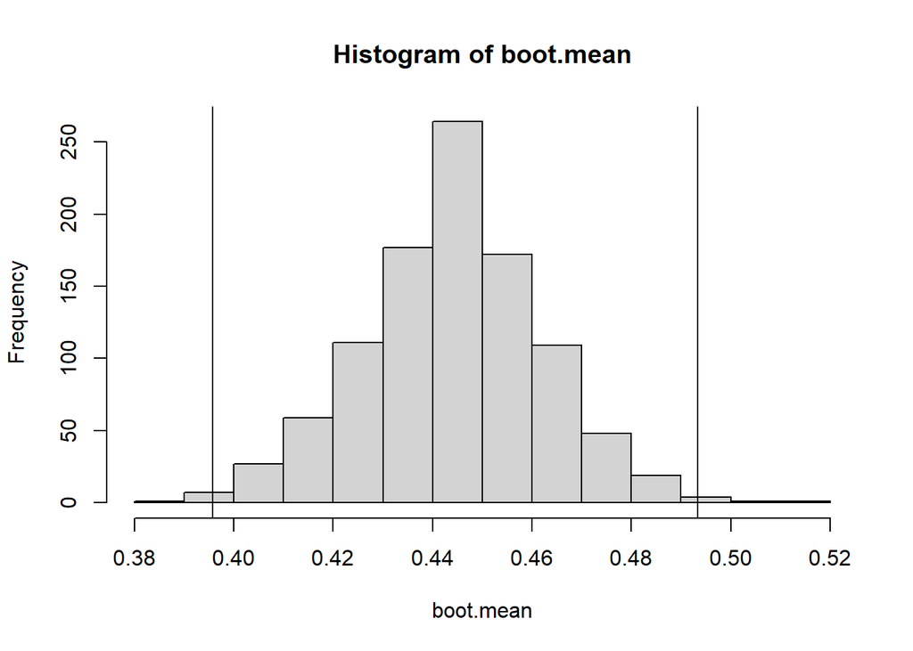

```r
hist(boot.mean)

abline(v=mean(quantile(boot.mean, probs = 0.005),col="red",lwd=12))
abline(v=mean(quantile(boot.mean, probs = 0.995),col="red",lwd=12))
```

```r
# 99% Confidence Interval:
c(quantile(boot.mean, probs = 0.005), quantile(boot.mean, probs = 0.995))
```

```
##      0.5%     99.5%
## 0.3957586 0.4934103
```

```r
### Another way to get the 99% confidence interval using boot package ###
boot_mean_func <- function(orig_vector, resample_vector) {
  mean(orig_vector[resample_vector])
}

# R is number of replications
mean_results <- boot(x, boot_mean_func, R = 1000)
tidy(mean_results)
```

```
## # A tibble: 1 × 3
##   statistic     bias std.error
##       <dbl>    <dbl>     <dbl>
## 1     0.445 0.000334    0.0181
```

```r
boot.ci(mean_results, conf=0.99)
```

```
## BOOTSTRAP CONFIDENCE INTERVAL CALCULATIONS
## Based on 1000 bootstrap replicates
##
## CALL :
## boot.ci(boot.out = mean_results, conf = 0.99)
##
## Intervals :
## Level      Normal              Basic
## 99%   ( 0.3976,  0.4909 )   ( 0.3984,  0.4908 )
##
## Level     Percentile            BCa
## 99%   ( 0.3984,  0.4908 )   ( 0.3964,  0.4892 )
## Calculations and Intervals on Original Scale
## Some basic intervals may be unstable
## Some percentile intervals may be unstable
## Some BCa intervals may be unstable
```